# 52414 - lab 1

dadosh_itai

4/4/2020

# *Lab 1: Basic Data Wrangling*

### Q1

### Data Preparation and Manipulation

(25 points)

1. We first prepare and aggregate the data.
1. First, load the `Corona Confirmed Cases Narrow`, the `Corona Confirmed Deaths Narrow`, and the `Corona Confirmed Recovered Narrow` datasets directly from the John’s Hopkins website.  
   The type of the `Date` variable should be date type. (2 pts)
2. Create new data-frames named `cases.agg`, `deaths.agg`, and `recovered.agg` which aggregate the `sum` of Corona cases, deaths, and recovered respectively over the different countries’ provinces. To do this, aggregate `Value` using only the country and date features, ignoring all other features (similarly to what has been shown in `lecture 2`).  
   To achieve the aggregation use the `aggregate` function. In addition, order the data-frame first by Country and then by Date (increasing order). The columns of each of the two resulting data-frames should be `Country.Region, Date, Value`. (5pts)
3. Repeat (b) using `tidyverse` and the pipe. Show that the outputs from the two methods are the same. (5pts)
4. Using the last day of March as a reference, create a single stacked bar-plot that visualizes the top 10 countries in terms of their Corona cases, and their respected Corona deaths and recovered cases stacked on top of the current sick people in three different colors (each stack should add up to total cases). Make sure that the first stack shows the number of confirmed Corona sick people (`sick = cases - deaths - recovered`). Each stacked bar should represent a country. Please use the barplot base R function to create this plot. I recommend everyone to read the help documentation for barplot ; go over the expected input, and the different parameters. What is the biggest issue with the information presented in this plot? (13pts)

**Solution:**

```r
# load the data
corona.confirmed.narrow <- read.csv(url("https://data.humdata.org/hxlproxy/data/download/time_series_covid19_confirmed_global_narrow.csv?dest=data_edit&filter01=merge&merge-url01=https%3A%2F%2Fdocs.google.com%2Fspreadsheets%2Fd%2Fe%2F2PACX-1vTglKQRXpkKSErDiWG6ycqEth32MY0reMuVGhaslImLjfuLU0EUgyyu2e-3vKDArjqGX7dXEBV8FJ4f%2Fpub%3Fgid%3D1326629740%26single%3Dtrue%26output%3Dcsv&merge-keys01=%23country%2Bname&merge-tags01=%23country%2Bcode%2C%23region%2Bmain%2Bcode%2C%23region%2Bsub%2Bcode%2C%23region%2Bintermediate%2Bcode&filter02=merge&merge-url02=https%3A%2F%2Fdocs.google.com%2Fspreadsheets%2Fd%2Fe%2F2PACX-1vTglKQRXpkKSErDiWG6ycqEth32MY0reMuVGhaslImLjfuLU0EUgyyu2e-3vKDArjqGX7dXEBV8FJ4f%2Fpub%3Fgid%3D398158223%26single%3Dtrue%26output%3Dcsv&merge-keys02=%23adm1%2Bname&merge-tags02=%23country%2Bcode%2C%23region%2Bmain%2Bcode%2C%23region%2Bsub%2Bcode%2C%23region%2Bintermediate%2Bcode&merge-replace02=on&merge-overwrite02=on&filter03=explode&explode-header-att03=date&explode-value-att03=value&filter04=rename&rename-oldtag04=%23affected%2Bdate&rename-newtag04=%23date&rename-header04=Date&filter05=rename&rename-oldtag05=%23affected%2Bvalue&rename-newtag05=%23affected%2Binfected%2Bvalue%2Bnum&rename-header05=Value&filter06=clean&clean-date-tags06=%23date&filter07=sort&sort-tags07=%23date&sort-reverse07=on&filter08=sort&sort-tags08=%23country%2Bname%2C%23adm1%2Bname&tagger-match-all=on&tagger-default-tag=%23affected%2Blabel&tagger-01-header=province%2Fstate&tagger-01-tag=%23adm1%2Bname&tagger-02-header=country%2Fregion&tagger-02-tag=%23country%2Bname&tagger-03-header=lat&tagger-03-tag=%23geo%2Blat&tagger-04-header=long&tagger-04-tag=%23geo%2Blon&header-row=1&url=https%3A%2F%2Fraw.githubusercontent.com%2FCSSEGISandData%2FCOVID-19%2Fmaster%2Fcsse_covid_19_data%2Fcsse_covid_19_time_series%2Ftime_series_covid19_confirmed_global.csv"), comment.char = "#")

corona.deaths.narrow <- read.csv(url("https://data.humdata.org/hxlproxy/data/download/time_series_covid19_deaths_global_narrow.csv?dest=data_edit&filter01=merge&merge-url01=https%3A%2F%2Fdocs.google.com%2Fspreadsheets%2Fd%2Fe%2F2PACX-1vTglKQRXpkKSErDiWG6ycqEth32MY0reMuVGhaslImLjfuLU0EUgyyu2e-3vKDArjqGX7dXEBV8FJ4f%2Fpub%3Fgid%3D1326629740%26single%3Dtrue%26output%3Dcsv&merge-keys01=%23country%2Bname&merge-tags01=%23country%2Bcode%2C%23region%2Bmain%2Bcode%2C%23region%2Bsub%2Bcode%2C%23region%2Bintermediate%2Bcode&filter02=merge&merge-url02=https%3A%2F%2Fdocs.google.com%2Fspreadsheets%2Fd%2Fe%2F2PACX-1vTglKQRXpkKSErDiWG6ycqEth32MY0reMuVGhaslImLjfuLU0EUgyyu2e-3vKDArjqGX7dXEBV8FJ4f%2Fpub%3Fgid%3D398158223%26single%3Dtrue%26output%3Dcsv&merge-keys02=%23adm1%2Bname&merge-tags02=%23country%2Bcode%2C%23region%2Bmain%2Bcode%2C%23region%2Bsub%2Bcode%2C%23region%2Bintermediate%2Bcode&merge-replace02=on&merge-overwrite02=on&filter03=explode&explode-header-att03=date&explode-value-att03=value&filter04=rename&rename-oldtag04=%23affected%2Bdate&rename-newtag04=%23date&rename-header04=Date&filter05=rename&rename-oldtag05=%23affected%2Bvalue&rename-newtag05=%23affected%2Binfected%2Bvalue%2Bnum&rename-header05=Value&filter06=clean&clean-date-tags06=%23date&filter07=sort&sort-tags07=%23date&sort-reverse07=on&filter08=sort&sort-tags08=%23country%2Bname%2C%23adm1%2Bname&tagger-match-all=on&tagger-default-tag=%23affected%2Blabel&tagger-01-header=province%2Fstate&tagger-01-tag=%23adm1%2Bname&tagger-02-header=country%2Fregion&tagger-02-tag=%23country%2Bname&tagger-03-header=lat&tagger-03-tag=%23geo%2Blat&tagger-04-header=long&tagger-04-tag=%23geo%2Blon&header-row=1&url=https%3A%2F%2Fraw.githubusercontent.com%2FCSSEGISandData%2FCOVID-19%2Fmaster%2Fcsse_covid_19_data%2Fcsse_covid_19_time_series%2Ftime_series_covid19_deaths_global.csv"), comment.char = "#")

corona.recovered.narrow <- read.csv(url("https://data.humdata.org/hxlproxy/data/download/time_series_covid19_recovered_global_narrow.csv?dest=data_edit&filter01=merge&merge-url01=https%3A%2F%2Fdocs.google.com%2Fspreadsheets%2Fd%2Fe%2F2PACX-1vTglKQRXpkKSErDiWG6ycqEth32MY0reMuVGhaslImLjfuLU0EUgyyu2e-3vKDArjqGX7dXEBV8FJ4f%2Fpub%3Fgid%3D1326629740%26single%3Dtrue%26output%3Dcsv&merge-keys01=%23country%2Bname&merge-tags01=%23country%2Bcode%2C%23region%2Bmain%2Bcode%2C%23region%2Bsub%2Bcode%2C%23region%2Bintermediate%2Bcode&filter02=merge&merge-url02=https%3A%2F%2Fdocs.google.com%2Fspreadsheets%2Fd%2Fe%2F2PACX-1vTglKQRXpkKSErDiWG6ycqEth32MY0reMuVGhaslImLjfuLU0EUgyyu2e-3vKDArjqGX7dXEBV8FJ4f%2Fpub%3Fgid%3D398158223%26single%3Dtrue%26output%3Dcsv&merge-keys02=%23adm1%2Bname&merge-tags02=%23country%2Bcode%2C%23region%2Bmain%2Bcode%2C%23region%2Bsub%2Bcode%2C%23region%2Bintermediate%2Bcode&merge-replace02=on&merge-overwrite02=on&filter03=explode&explode-header-att03=date&explode-value-att03=value&filter04=rename&rename-oldtag04=%23affected%2Bdate&rename-newtag04=%23date&rename-header04=Date&filter05=rename&rename-oldtag05=%23affected%2Bvalue&rename-newtag05=%23affected%2Binfected%2Bvalue%2Bnum&rename-header05=Value&filter06=clean&clean-date-tags06=%23date&filter07=sort&sort-tags07=%23date&sort-reverse07=on&filter08=sort&sort-tags08=%23country%2Bname%2C%23adm1%2Bname&tagger-match-all=on&tagger-default-tag=%23affected%2Blabel&tagger-01-header=province%2Fstate&tagger-01-tag=%23adm1%2Bname&tagger-02-header=country%2Fregion&tagger-02-tag=%23country%2Bname&tagger-03-header=lat&tagger-03-tag=%23geo%2Blat&tagger-04-header=long&tagger-04-tag=%23geo%2Blon&header-row=1&url=https%3A%2F%2Fraw.githubusercontent.com%2FCSSEGISandData%2FCOVID-19%2Fmaster%2Fcsse_covid_19_data%2Fcsse_covid_19_time_series%2Ftime_series_covid19_recovered_global.csv"), comment.char = "#")

# Q1 - a

# give coulm's title for each data by define new object
data.cor.confirmed <- corona.confirmed.narrow[c("Country.Region", "Date", "Value")]
data.cor.confirmed$Date = as.Date(data.cor.confirmed$Date)

data.cor.deaths <- corona.deaths.narrow[c("Country.Region", "Date", "Value")]
data.cor.deaths$Date = as.Date(data.cor.deaths$Date)

data.cor.recovered <- corona.recovered.narrow[c("Country.Region", "Date", "Value")]
data.cor.recovered$Date = as.Date(data.cor.recovered$Date)


# Q1 - b

# sum values by Country Region and Date for each data
cases.agg <- aggregate(Value ~ Country.Region + Date, data = data.cor.confirmed, FUN = sum)
deaths.agg <- aggregate(Value ~ Country.Region + Date, data = data.cor.deaths, FUN = sum)
recovered.agg <- aggregate(Value ~ Country.Region + Date, data = data.cor.recovered, FUN =  sum)


# Q1 - c

# tidyverse option
tidyverse.sum.confirmed <- data.cor.confirmed %>% group_by(Country.Region, Date) %>% summarise(value = sum(Value)) %>% arrange(Date)
tidyverse.sum.deaths <- data.cor.deaths %>% group_by(Country.Region, Date) %>% summarise(Value = sum()) %>% arrange(Date)
tidyverse.sum.recovered <- data.cor.recovered %>% group_by(Country.Region, Date) %>% summarise(Value = sum()) %>% arrange(Date)
identical(tidyverse.sum.confirmed, cases.agg) # I dont know why it's False
```

```
## [1] FALSE
```

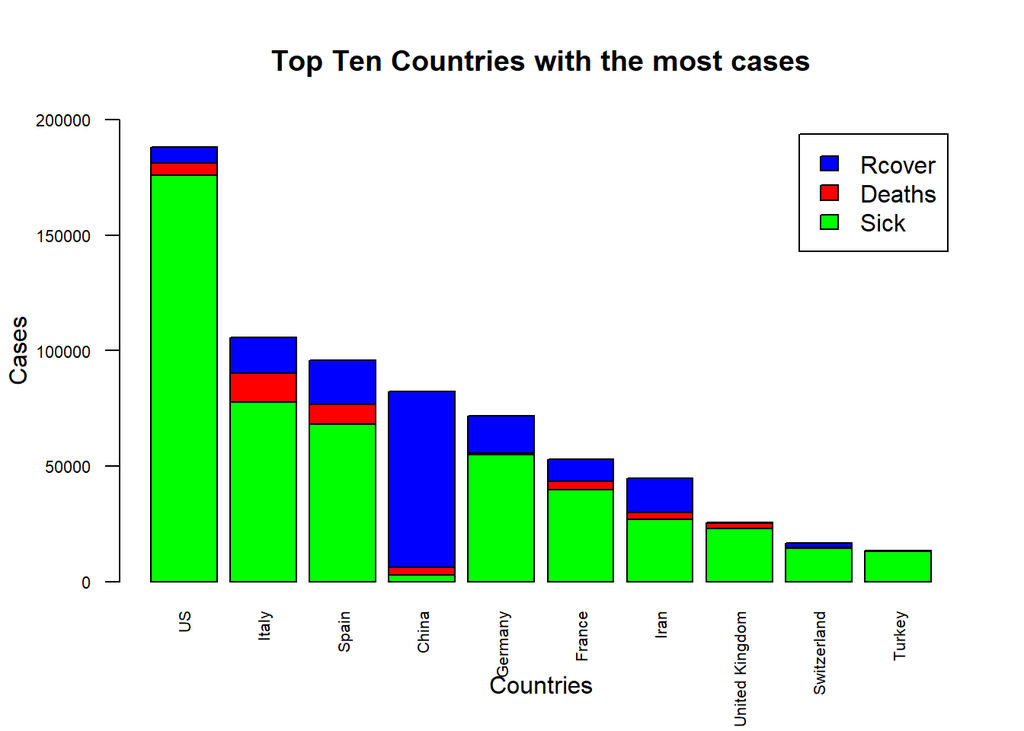

```r
# Q1 - d

# Slice for spesipic Date in each data
ref.date <- '2020-03-31' # required date
confirmed.agg.ref.date <- cases.agg[which(cases.agg$Date==ref.date),]
confirmed.agg.ref.date.sort <- confirmed.agg.ref.date[order(-confirmed.agg.ref.date$Value),]
top.ten <- head(confirmed.agg.ref.date.sort, 10) # Top ten countries in Corona cases
top.ten.vec <-top.ten[,1]

recovered.agg.ref.date <- recovered.agg[which(recovered.agg$Date==ref.date),]
recovered.agg.ref.date.sort <- recovered.agg.ref.date %>% filter(Country.Region %in% top.ten.vec)

deaths.agg.ref.date <- deaths.agg[which(deaths.agg$Date==ref.date),]
deaths.agg.ref.date.sort <- deaths.agg.ref.date %>% filter(Country.Region %in% top.ten.vec)

# merge the 3 data tables
merge.for.plot <-merge.data.frame(confirmed.agg.ref.date.sort, recovered.agg.ref.date.sort, by = "Country.Region") %>% merge(deaths.agg.ref.date.sort, by = "Country.Region")

# sorting and renames the colums for each coulums the data table it come from
merge.for.plot.sort <- merge.for.plot[order(-merge.for.plot$Value.x),][,c(1,3,5,7)]
names(merge.for.plot.sort)[2] <- "Cases"
names(merge.for.plot.sort)[3] <- "Rcover"
names(merge.for.plot.sort)[4] <- "Deaths"

# Calculate the Sick people, Sick = Cases - deaths - recover
merge.for.plot.sort$Sick <- c(merge.for.plot.sort$Cases - merge.for.plot.sort$Rcover - merge.for.plot.sort$Deaths)

# Manipulate on the data frame for plot output
merge.for.plot.sort.t = t(merge.for.plot.sort)
colnames(merge.for.plot.sort.t) <- as.character(unlist(merge.for.plot.sort.t[1,]))
merge.for.plot.sort.t = merge.for.plot.sort.t[-1,]

# Barplot
barplot(merge.for.plot.sort.t[c(4,3,2),], las = 2, legend.text = T, ylim =  c(0, 200000), xlab = "Countries", ylab = "Cases", col = c("green", "red", "blue"), main = "Top Ten Countries with the most cases", cex.axis = 0.7, cex.names = 0.65)
```